# ASSOCIATION RULES - APRIORI ALGORITHM ON THE GROCERY BASKET DATA

Nurdan Beşli  
01.03.2023

## INTRODUCTION

Association rule mining is a popular technique in unsupervised learning that aims to discover relationships between variables in a dataset. These relationships are represented as “if-then” rules that can be used to make predictions or generate insights. In real life, association rule mining has many applications, such as market basket analysis in retail, fraud detection in finance, and customer segmentation in marketing. By identifying patterns and relationships in large datasets, association rule mining can help businesses make more informed decisions and improve their bottom line (Agrawal & Srikant, 1994; Tan, Steinbach, & Kumar, 2006).

Support, confidence, and lift are important measures used in association rule mining to evaluate the strength and significance of relationships between variables in a dataset.

**Support** measures the frequency with which a rule occurs in the dataset and is calculated as the number of transactions that contain both items in the rule divided by the total number of transactions (Han & Kamber, 2006).

**Confidence** measures the strength of the relationship between two items in the rule and is calculated as the number of transactions that contain both items in the rule divided by the number of transactions that contain the antecedent item (Tan, Steinbach, & Kumar, 2006).

**Lift** is used to determine the degree to which the occurrence of one item is dependent on the occurrence of another item and is calculated as the ratio of the observed frequency of co-occurrence to the expected frequency of co-occurrence under the assumption of independence (Han & Kamber, 2006).

The aim of this project is to use association rules - apriori algorithm on the grocery basket dataset. The dataset was taken from [Kaglle](https://www.kaggle.com/code/rashikrahmanpritom/apriori-implementation/data?select=basket.csv).

## DATA REVIEW

```r
inspect(data[1:10])
```

```
##      items
## [1]  {pastry, salty snack, whole milk}
## [2]  {sausage, semi-finished bread, whole milk, yogurt}
## [3]  {pickled vegetables, soda}
## [4]  {canned beer, misc. beverages}
## [5]  {hygiene articles, sausage}
## [6]  {rolls/buns, sausage, whole milk}
## [7]  {soda, whole milk}
## [8]  {frankfurter, soda, whipped/sour cream}
## [9]  {curd, frankfurter}
## [10] {beef, white bread}
```

The dataset contains 14963 rows, which means that there are 14963 transactions (or itemsets) in the dataset. The 167 columns indicate that there are 167 unique items in the dataset. The density of the matrix is 0.01520957, which means that only 1.5% of the cells in the matrix contain non-zero values. This confirms that the dataset is sparse.

The summary also shows the most frequent items in the dataset. Whole milk is the most common item, appearing in 2363 transactions, followed by other vegetables (1827 transactions), rolls/buns (1646 transactions), soda (1453 transactions), yogurt (1285 transactions), and Other (29432 transactions). Other refers to all items other than the top 5 most frequent items.

The distribution of element (itemset/transaction) length is also shown in the summary. The most common transaction length is two items, which appears in 10012 transactions. The distribution shows that the majority of transactions are between one and four items in length.

```r
summary(data)
```

```
## transactions as itemMatrix in sparse format with
##  14963 rows (elements/itemsets/transactions) and
##  167 columns (items) and a density of 0.01520957
##
## most frequent items:
##       whole milk other vegetables       rolls/buns             soda
##             2363             1827             1646             1453
##           yogurt          (Other)
##             1285            29432
##
## element (itemset/transaction) length distribution:
## sizes
##     1     2     3     4     5     6     7     8     9    10
##   205 10012  2727  1273   338   179   113    96    19     1
##
##    Min. 1st Qu.  Median    Mean 3rd Qu.    Max.
##    1.00    2.00    2.00    2.54    3.00   10.00
##
## includes extended item information - examples:
##             labels
## 1 abrasive cleaner
## 2 artif. sweetener
## 3   baby cosmetics
```

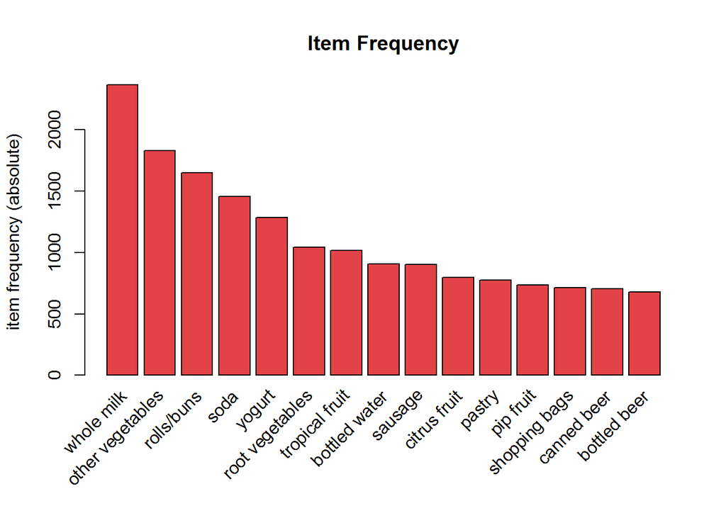

```r
itemFrequencyPlot(data, topN = 15, type="absolute", col="#E34347", main="Item Frequency")
```

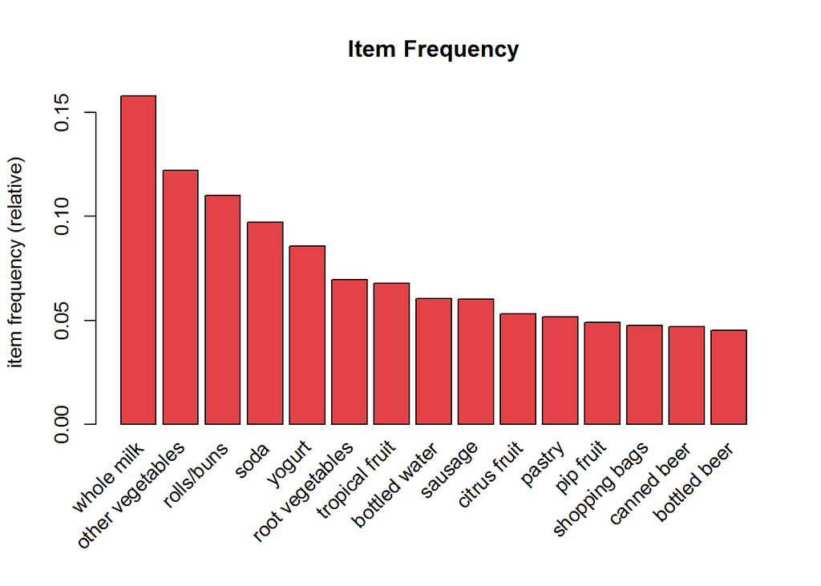

```r
itemFrequencyPlot(data, topN = 15, type="relative", col="#E34347", main="Item Frequency")
```

The below graph depict a group of 200 transactions that were chosen randomly from the complete dataset. The X-axis represents 167 products that were examined, and the Y-axis represents the 200 transaction samples. The black dots displayed on the graphs denote the items that were included in the selected transactions.

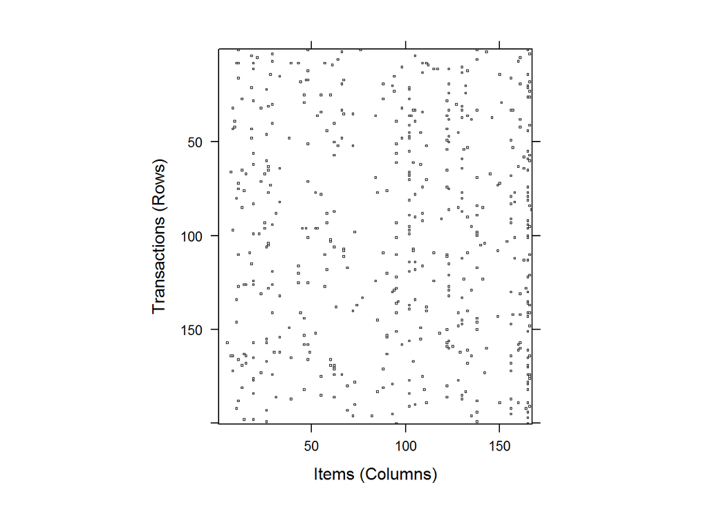

```r
image(sample(data, 200))
```

## APRIORI ALGORITM

The Apriori algorithm is a widely used data mining algorithm for discovering frequent itemsets in a dataset. This algorithm utilizes a breadth-first search strategy to generate candidate itemsets, and then removes the infrequent itemsets at each iteration. The primary goal of the Apriori algorithm is to identify association rules between items in a transactional database. This can be useful in various applications such as market basket analysis, where one can determine which products are often purchased together (Agrawal & Srikant, 1994; Han & Kamber, 2006).

The below code, the Apriori algorithm was applied with default values (minimum support = 0.1, minimum confidence = 0.8).

```r
datarules <- apriori(data)
```

```
## Apriori
##
## Parameter specification:
##  confidence minval smax arem  aval originalSupport maxtime support minlen
##         0.8    0.1    1 none FALSE            TRUE       5     0.1      1
##  maxlen target  ext
##      10  rules TRUE
##
## Algorithmic control:
##  filter tree heap memopt load sort verbose
##     0.1 TRUE TRUE  FALSE TRUE    2    TRUE
##
## Absolute minimum support count: 1496
##
## set item appearances ...[0 item(s)] done [0.00s].
## set transactions ...[167 item(s), 14963 transaction(s)] done [0.01s].
## sorting and recoding items ... [3 item(s)] done [0.00s].
## creating transaction tree ... done [0.00s].
## checking subsets of size 1 2 done [0.00s].
## writing ... [0 rule(s)] done [0.00s].
## creating S4 object  ... done [0.00s].
```

```r
datarules
```

```
## set of 0 rules
```

As it can be seen in the result above, there is no any rules found for both sets of transactions.

The apriori algorithm was applied again with lower thresholds. The threshold of minimum support was reduced to 0.005, and threshold of minimum confidence was lowered to 0.1.

```r
datarules <- apriori(data, parameter = list(support = 0.005, confidence = 0.1, minlen = 2))
```

```
## Apriori
##
## Parameter specification:
##  confidence minval smax arem  aval originalSupport maxtime support minlen
##         0.1    0.1    1 none FALSE            TRUE       5   0.005      2
##  maxlen target  ext
##      10  rules TRUE
##
## Algorithmic control:
##  filter tree heap memopt load sort verbose
##     0.1 TRUE TRUE  FALSE TRUE    2    TRUE
##
## Absolute minimum support count: 74
##
## set item appearances ...[0 item(s)] done [0.00s].
## set transactions ...[167 item(s), 14963 transaction(s)] done [0.01s].
## sorting and recoding items ... [89 item(s)] done [0.00s].
## creating transaction tree ... done [0.01s].
## checking subsets of size 1 2 3 done [0.00s].
## writing ... [19 rule(s)] done [0.00s].
## creating S4 object  ... done [0.00s].
```

```r
datarules
```

```
## set of 19 rules
```

Finally, 19 rules for transactions were found by applying apriori algoritm with lower thresholds of support and confidence.

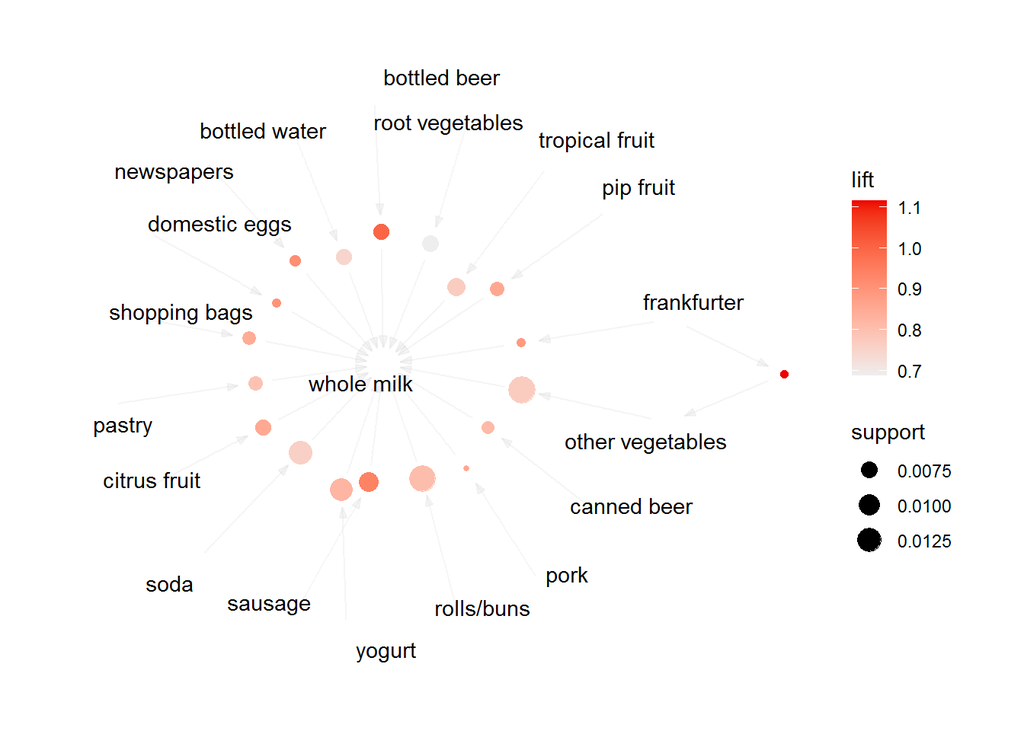

```r
plot(datarules, method="graph")
```

```
## Itemsets in Antecedent (LHS)
##  [1] "{frankfurter}"      "{bottled beer}"     "{sausage}"
##  [4] "{newspapers}"       "{domestic eggs}"    "{pork}"
##  [7] "{pip fruit}"        "{citrus fruit}"     "{shopping bags}"
## [10] "{yogurt}"           "{canned beer}"      "{rolls/buns}"
## [13] "{pastry}"           "{other vegetables}" "{tropical fruit}"
## [16] "{soda}"             "{bottled water}"    "{root vegetables}"
## Itemsets in Consequent (RHS)
## [1] "{whole milk}"       "{other vegetables}"
```

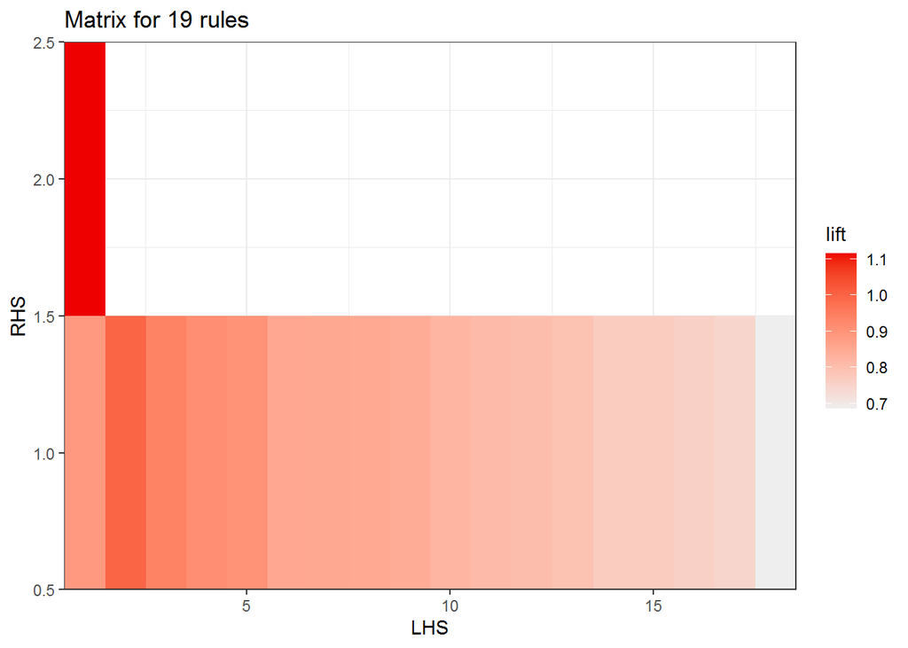

```r
plot(datarules, method="matrix", measure="lift")
```

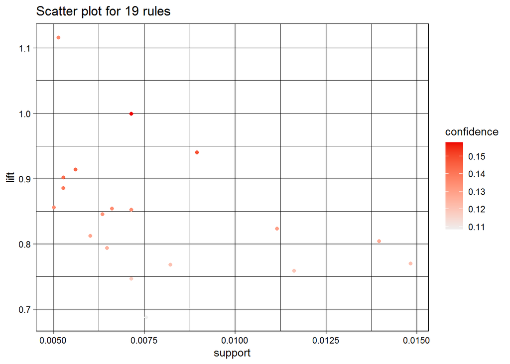

```r
plot(datarules, measure=c("support","lift"), shading="confidence")
```

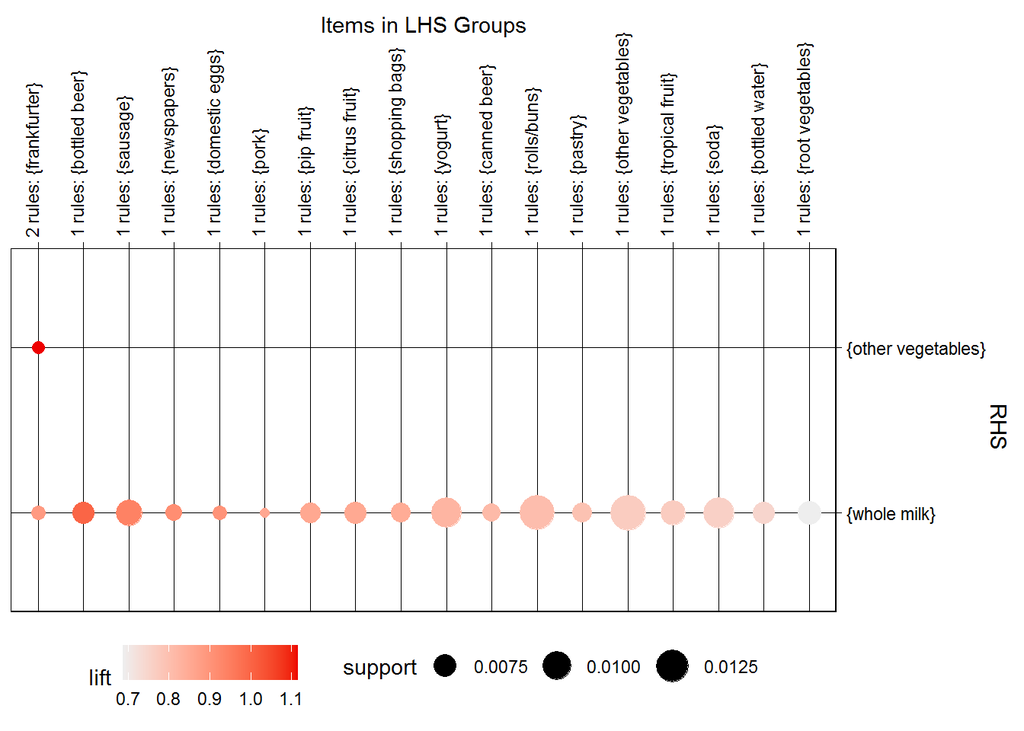

```r
plot(datarules, method="grouped")
```

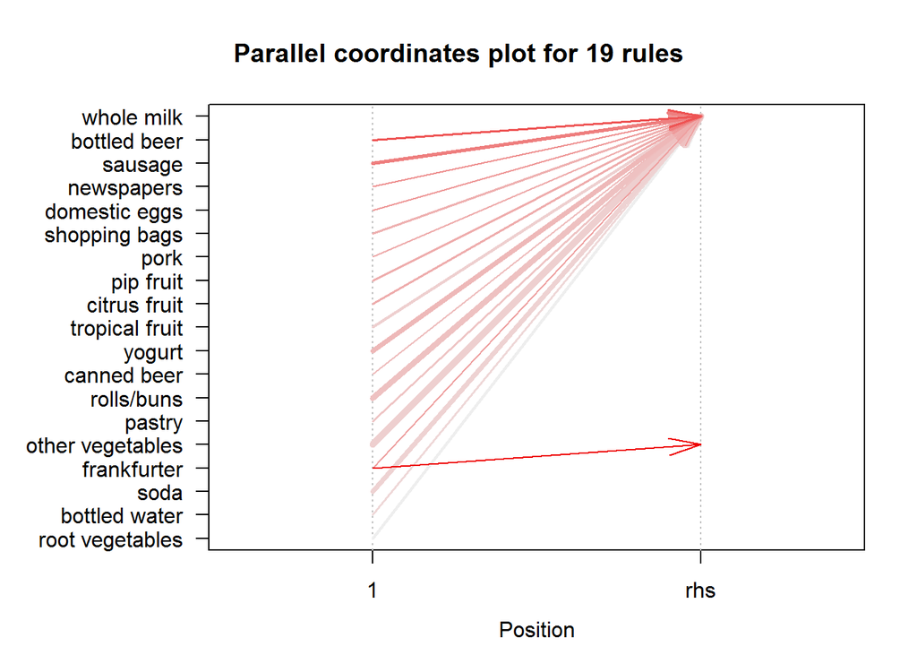

```r
plot(datarules, method="paracoord", control=list(reorder=TRUE))
```

## EVALUATION OF RESULTS

The below tables show the top 10 association rules generated by the Apriori algorithm with their corresponding support, confidence, coverage, and lift metrics. Each row in the table represents a rule and includes the following columns:  
**LHS:** The left-hand side of the rule, i.e., the antecedent.  
**RHS:** The right-hand side of the rule, i.e., the consequent.  
**Support:** The proportion of transactions that contain both the antecedent and the consequent.  
**Confidence:** The proportion of transactions that contain the antecedent and also contain the consequent.  
**Coverage:** The proportion of transactions that contain the antecedent.  
**Lift:** A measure of the strength of the association between the antecedent and the consequent, with values greater than 1 indicating a positive association.  
**Count:** The number of transactions that contain both the antecedent and the consequent.

```r
inspect(sort(datarules, by = "support")[1:10])
```

```
##      lhs                   rhs          support     confidence coverage
## [1]  {other vegetables} => {whole milk} 0.014836597 0.1215107  0.12210118
## [2]  {rolls/buns}       => {whole milk} 0.013967787 0.1269745  0.11000468
## [3]  {soda}             => {whole milk} 0.011628684 0.1197522  0.09710620
## [4]  {yogurt}           => {whole milk} 0.011160863 0.1299611  0.08587850
## [5]  {sausage}          => {whole milk} 0.008955423 0.1483942  0.06034886
## [6]  {tropical fruit}   => {whole milk} 0.008220277 0.1213018  0.06776716
## [7]  {root vegetables}  => {whole milk} 0.007551962 0.1085495  0.06957161
## [8]  {bottled beer}     => {whole milk} 0.007150972 0.1578171  0.04531177
## [9]  {citrus fruit}     => {whole milk} 0.007150972 0.1345912  0.05313106
## [10] {bottled water}    => {whole milk} 0.007150972 0.1178414  0.06068302
##      lift      count
## [1]  0.7694305 222
## [2]  0.8040284 209
## [3]  0.7582957 174
## [4]  0.8229402 167
## [5]  0.9396627 134
## [6]  0.7681077 123
## [7]  0.6873575 113
## [8]  0.9993303 107
## [9]  0.8522590 107
## [10] 0.7461959 107
```

```r
inspect(sort(datarules, by = "confidence")[1:10])
```

```
##      lhs                rhs                support     confidence coverage
## [1]  {bottled beer}  => {whole milk}       0.007150972 0.1578171  0.04531177
## [2]  {sausage}       => {whole milk}       0.008955423 0.1483942  0.06034886
## [3]  {newspapers}    => {whole milk}       0.005613847 0.1443299  0.03889594
## [4]  {domestic eggs} => {whole milk}       0.005279690 0.1423423  0.03709149
## [5]  {frankfurter}   => {whole milk}       0.005279690 0.1398230  0.03775981
## [6]  {frankfurter}   => {other vegetables} 0.005146027 0.1362832  0.03775981
## [7]  {pork}          => {whole milk}       0.005012364 0.1351351  0.03709149
## [8]  {pip fruit}     => {whole milk}       0.006616320 0.1348774  0.04905433
## [9]  {citrus fruit}  => {whole milk}       0.007150972 0.1345912  0.05313106
## [10] {shopping bags} => {whole milk}       0.006348994 0.1334270  0.04758404
##      lift      count
## [1]  0.9993303 107
## [2]  0.9396627 134
## [3]  0.9139265  84
## [4]  0.9013409  79
## [5]  0.8853879  79
## [6]  1.1161496  77
## [7]  0.8557034  75
## [8]  0.8540712  99
## [9]  0.8522590 107
## [10] 0.8448869  95
```

Overall, the results suggest that whole milk is a popular item that is frequently purchased with other groceries. The association rules can be used to guide marketing and product placement strategies to increase sales of whole milk and other items that are frequently purchased together.

```r
inspect(sort(datarules, by = "lift")[1:10])
```

```
##      lhs                rhs                support     confidence coverage
## [1]  {frankfurter}   => {other vegetables} 0.005146027 0.1362832  0.03775981
## [2]  {bottled beer}  => {whole milk}       0.007150972 0.1578171  0.04531177
## [3]  {sausage}       => {whole milk}       0.008955423 0.1483942  0.06034886
## [4]  {newspapers}    => {whole milk}       0.005613847 0.1443299  0.03889594
## [5]  {domestic eggs} => {whole milk}       0.005279690 0.1423423  0.03709149
## [6]  {frankfurter}   => {whole milk}       0.005279690 0.1398230  0.03775981
## [7]  {pork}          => {whole milk}       0.005012364 0.1351351  0.03709149
## [8]  {pip fruit}     => {whole milk}       0.006616320 0.1348774  0.04905433
## [9]  {citrus fruit}  => {whole milk}       0.007150972 0.1345912  0.05313106
## [10] {shopping bags} => {whole milk}       0.006348994 0.1334270  0.04758404
##      lift      count
## [1]  1.1161496  77
## [2]  0.9993303 107
## [3]  0.9396627 134
## [4]  0.9139265  84
## [5]  0.9013409  79
## [6]  0.8853879  79
## [7]  0.8557034  75
## [8]  0.8540712  99
## [9]  0.8522590 107
## [10] 0.8448869  95
```

The final table above is sorted by the lift measure from high to low, which is a measure of the strength of the association between the items in the rule. The top rule in the table shows that customers who purchase frankfurter are 1.12 times more likely to purchase other vegetables compared to the overall probability of purchasing other vegetables. The support of this rule is 0.0051, which means that about 0.51% of transactions contain both frankfurter and other vegetables. The confidence is 0.136, which means that 13.6% of transactions that contain frankfurter also contain other vegetables. The coverage is 0.038, which means that 3.8% of transactions contain frankfurter. The count is 77, which means that this rule applies to 77 transactions in the dataset.

Similarly, the other rules in the table can be interpreted in a similar way. The lift measure can be used to identify the most interesting rules that have a strong association between the antecedent and the consequent. However, it is important to keep in mind that a high lift value does not necessarily mean that the rule is useful or actionable in practice. It is always important to interpret the rules in the context of the problem and the domain knowledge.

## REFERENCES

Agrawal, R., & Srikant, R. (1994). Fast algorithms for mining association rules in large databases. In Proceedings of the 20th International Conference on Very Large Data Bases (pp. 487-499).

Han, J., & Kamber, M. (2006). Data mining: Concepts and techniques (2nd ed.). San Francisco, CA: Morgan Kaufmann.

Tan, P. N., Steinbach, M., & Kumar, V. (2006). Introduction to data mining (1st ed.). Boston, MA: Pearson Addison Wesley.